# APLS study

Total mothers

```
[1] 91
```

[output not shown]

| total_pregnancies |
| --- |
| 369 |

Checking for clinical criteria

| criterion | n |
| --- | --- |
| 1 | 63 |
| 2 | 1 |
| 3 | 14 |
| no | 13 |

After correcting for criteria

| Total.mothers | Total.pregnancie |
| --- | --- |
| 78 | 313 |

Treatment

| Aspirin_only | LMWH_only | Either | None | Both | Aspirin | LMWH |
| --- | --- | --- | --- | --- | --- | --- |
| 25 | 8 | 67 | 246 | 34 | 59 | 42 |

demography

number of pregnancies

```
  0%  25%  50%  75% 100%
   1    3    4    5    9
```

Age

PIH

| PIH | percent - out of pregnancies |
| --- | --- |
| 17 | 5.43131 |

Other Medical conditions

| condition | n | percent - out of mothers |
| --- | --- | --- |
| Hypothyroidism | 2 | 2.197802 |

Investigations Any of the 5 investigations

| Any investigation | precent - of mothers |
| --- | --- |
| 26 | 33.33333 |

Any of Lupus, APLS, cardiolipin, beta2

Proportion of a positive result

| Any investigation out of Lupus, cardio, beta, APLS | precent - of mothers |
| --- | --- |
| 25 | 32.05128 |

| positive subjects | percent of tested |
| --- | --- |
| 11 | 44 |

Previous pregnancy outcome without specific treatment

| total pregnancies |
| --- |
| 246 |

| successful pregnancies |
| --- |
| 36 |

| failed pregnancies |
| --- |
| 210 |

| success rate |
| --- |
| 14.63415 |

| MC before 10 wk |
| --- |
| 89 |

| MC at or after 10 wk |
| --- |
| 112 |

Previous pregnancy outcome - Treated by either Aspirin or LMWH

| total pregnancies |
| --- |
| 67 |

| successful pregnancies |
| --- |
| 32 |

| failed pregnancies |
| --- |
| 35 |

| success rate |
| --- |
| 47.76119 |

| MC before 10 wk |
| --- |
| 6 |

| MC at or after 10 wk |
| --- |
| 28 |

Previous pregnancy outcome - Treated Aspirin and LMWH

| total pregnancies |
| --- |
| 34 |

| successful pregnancies |
| --- |
| 23 |

| failed pregnancies |
| --- |
| 11 |

| success rate |
| --- |
| 67.64706 |

| MC before 10 wk |
| --- |
| 3 |

| MC at or after 10 wk |
| --- |
| 7 |

Previous pregnancy outcome - Treated Aspirin alone

| total pregnancies |
| --- |
| 25 |

| successful pregnancies |
| --- |
| 5 |

| failed pregnancies |
| --- |
| 20 |

| success rate |
| --- |
| 20 |

| MC before 10 wk |
| --- |
| 3 |

| MC at or after 10 wk |
| --- |
| 17 |

Previous pregnancy outcome - Treated LMWH alone

| total pregnancies |
| --- |
| 8 |

| successful pregnancies |
| --- |
| 4 |

| failed pregnancies |
| --- |
| 4 |

| success rate |
| --- |
| 50 |

| MC before 10 wk |
| --- |
| 0 |

| MC at or after 10 wk |
| --- |
| 4 |

comparison

No treatment vs any

| estimate1 | estimate2 | statistic | p.value | parameter | conf.low | conf.high | method | alternative |
| --- | --- | --- | --- | --- | --- | --- | --- | --- |
| 0.4776119 | 0.1463415 | 32.06155 | 7.468204e-09 | 1 | 0.2147752 | 1 | 2-sample test for equality of proportions with continuity correction | greater |

No treatment vs both

| estimate1 | estimate2 | statistic | p.value | parameter | conf.low | conf.high | method | alternative |
| --- | --- | --- | --- | --- | --- | --- | --- | --- |
| 0.6764706 | 0.1463415 | 47.33951 | 2.984829e-12 | 1 | 0.3763158 | 1 | 2-sample test for equality of proportions with continuity correction | greater |

No treatment vs asp

```
Chi-squared approximation may be incorrect
```

| estimate1 | estimate2 | statistic | p.value | parameter | conf.low | conf.high | method | alternative |
| --- | --- | --- | --- | --- | --- | --- | --- | --- |
| 0.2 | 0.1463415 | 0.1767753 | 0.3370796 | 1 | -0.1050833 | 1 | 2-sample test for equality of proportions with continuity correction | greater |

No treatment vs LMWH

```
Chi-squared approximation may be incorrect
```

| estimate1 | estimate2 | statistic | p.value | parameter | conf.low | conf.high | method | alternative |
| --- | --- | --- | --- | --- | --- | --- | --- | --- |
| 0.5 | 0.1463415 | 4.881569 | 0.01357247 | 1 | -0.003998843 | 1 | 2-sample test for equality of proportions with continuity correction | greater |

ASP treatment vs LMWH

```
Chi-squared approximation may be incorrect
```

| estimate1 | estimate2 | statistic | p.value | parameter | conf.low | conf.high | method | alternative |
| --- | --- | --- | --- | --- | --- | --- | --- | --- |
| 0.5 | 0.2 | 1.445469 | 0.2292564 | 1 | -0.1628037 | 0.7628037 | 2-sample test for equality of proportions with continuity correction | two.sided |

ASP treatment vs both

| estimate1 | estimate2 | statistic | p.value | parameter | conf.low | conf.high | method | alternative |
| --- | --- | --- | --- | --- | --- | --- | --- | --- |
| 0.6764706 | 0.2 | 11.27543 | 0.0003926976 | 1 | 0.255402 | 1 | 2-sample test for equality of proportions with continuity correction | greater |

LMWH treatment vs both

```
Chi-squared approximation may be incorrect
```

| estimate1 | estimate2 | statistic | p.value | parameter | conf.low | conf.high | method | alternative |
| --- | --- | --- | --- | --- | --- | --- | --- | --- |
| 0.6764706 | 0.5 | 0.2779412 | 0.2990269 | 1 | -0.220053 | 1 | 2-sample test for equality of proportions with continuity correction | greater |

#### results

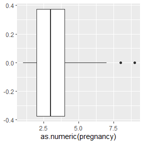

The mean age of the selected mothers was 32.1428571 with a standard deviation of 5.1317235.

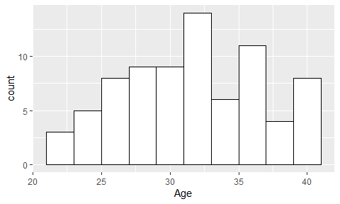

17 pregnancies were complicated with PIH.

| PIH | percent - out of pregnancies |
| --- | --- |
| 17 | 5.43131 |

Outcome by treatment group

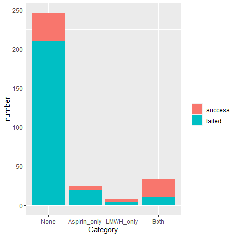

The rate of live births among mothers who were not received specific treatment for APS was 0.1463415. In contrast, 67 gestations were treated with either aspirin, LMWH or both and the rate of successful outcome was 0.4776119

Outcome in each group is summarized below

| Category | n | live births | live birth rate |
| --- | --- | --- | --- |
| None | 246 | 36 | 14.63415 |
| Aspirin only | 25 | 5 | 20.00000 |
| LMWH only | 8 | 4 | 50.00000 |
| Both | 34 | 23 | 67.64706 |

Investigations  
25 (32.0512821%) mothers had undergone any of antibody tests for APL and out of them, 11 (44%) yeilded a positive result.

| Lupus | cardiolipin | beta 2 microglobulin | APL |
| --- | --- | --- | --- |
| 22 | 19 | 5 | 6 |

Live rates between test positives and negatives

```
Chi-squared approximation may be incorrect
```

Number of pregnancies that were treated, in mothers who were tested for antibodies was 19. Out of them, 10 (52.6315789%) mothers tested positive for at least one test and the success rate was 0.2. 9 (47.3684211%) mothers had negative results and success rate among them was 0.2222222